# VAR Predictability Benchmark

Descriptives

Author

Affiliation

Björn S. Siepe

University of Marburg

Published

November 17, 2026

# 1 Preparation

This is the summary script for all basic descriptives of our project prior to the main analyses.

# 2 Study design

```r
registry |>
  arrange(first_author, year) |>
  select(label, n_days, n_beeps_per_day, n_time_points, sampling_scheme, lag_mode, topics) |>
  knitr::kable(col.names = c("Dataset", "Days", "Beeps per day", "Planned time points",
                             "Sampling scheme", "Lag mode", "Topics"))
```

Table 1: Study design per dataset.

| Dataset | Days | Beeps per day | Planned time points | Sampling scheme | Lag mode | Topics |
| --- | --- | --- | --- | --- | --- | --- |
| Bosley (2019) | 19 | 4 | 45 | 4x/day 30-minute interval | within_day | GAD, affect, dampening |
| Contreras (2020) | 7 | 10 | 70 | 10x/day stratified sampling | within_day | paranoia, sadness, closeness to others, avoidance |
| Drukker (2020) | 7 | 10 | 70 | 10x/day random schedule | within_day | irritable bowel syndrome, panic disorder, gastrointestinal symptoms, childhood trauma |
| Fisher (2017) | 55 | 4 | 212 | 4x/day fixed schedule | within_day | mood, anxiety, procrastination, depression |
| Fried (2021) | 14 | 4 | 56 | 4x/day fixed schedule | within_day | mental health, social contact, COVID |
| Geschwind (2013) | 20 | 10 | 200 | 10x/day 90-minute interval | within_day | depression, neuroticism, mood |
| Grommisch (2020) | 21 | 9 | 189 | 9x/day semi-fixed intervals | within_day | emotion regulation, rumination, well-being |
| Kullar (2023) | 14 | 5 | 70 | 5x/day fixed 30-minute interval | within_day | affect, affective chronometry, mood disorders, mind wandering |
| Kuppens (2016) | 7 | 10 | 70 | 10x/day random 90-minute intervals | within_day | neuroticism, affect, emotion |
| Marian (2022) | 21 | 3 | 63 | 4x/day 4 hour intervals based on individual wake-up time | within_day | depression, anxiety, COVID |
| Merolla (2022) | 10 | 6 | 60 | 6x/day random schedule | within_day | responsiveness, social connection, hope, life satisfaction |
| Nestler (2022) | 82 | 1 | 82 | 1x/day unclear schedule | daily | personality, affect, motivation |
| Neubauer (2020) | 21 | 1 | 21 | 1x/day at 7pm completed until 5am | daily | COVID, schooling, adolescents, family |
| Pavani (2017) | 14 | 5 | 70 | 5x/day fixed-schedule with personalization | within_day | affect regulation, affect, personality |
| Reeves (2020) | 43 | 4 | 168 | 4x/day fixed schedule | within_day | PTSD, emotions, sleep, physical symptoms |
| Rowland (2020) | 40 | 6 | 240 | 6x/day random timing | within_day | mindfulness, affect, network |
| Wang (2024) | 21 | 7 | 147 | 6x/day EMA, 1x/day daily diary, morning survey at self-chosen time, other surveys randomly with certain interval, daily diary at 6:30pm | within_day | family conflict, social interactions, affect, emotion, sadness |
| Westhoff (2024) | 21 | 5 | 105 | 5x/day semi-random schedule | within_day | psychological flexibility, cognition, affect |
| Wright (2019) | 100 | 1 | 100 | 1x/day in the evening | daily | personality disorder, interpersonal behavior, stress, affect, functioning |
| van Woerkom (2022) | 5 | 10 | 50 | 10x/day in 90-minute blocks with 30 to 150 minutes in between | within_day | happiness, well-being, affect, need for autonomy |

# 3 Items

We summarise the items per dataset. The mean and share at the bounds refer to the rescaled items. Items allowed outside their bounds can lie outside [0, 1], so their share at the bounds is not applicable (NA). SD and lag-1 autocorrelation (first training window) are medians over persons. Missing is the share of scheduled beeps without a response, from a person’s first to last recorded day, including beeps absent from the raw data. Scheduled days outside this span are unknown, so this may still underestimate missingness. For datasets without day or beep information, only recorded rows are counted.

```r
item_person <- features$item |>
  summarise(sd_median = median(sd_obs, na.rm = TRUE),
            rho1_median = median(rho1_train, na.rm = TRUE),
            prop_bound_mean = mean(prop_bound, na.rm = TRUE),
            .by = c(dataset_id, variable))

item_series <- features$series |>
  summarise(mean_rescaled = mean(y, na.rm = TRUE),
            pct_missing = 100 * mean(is.na(y)),
            .by = c(dataset_id, variable))

items <- scale_bounds |>
  rename(variable = name) |>
  inner_join(item_person, by = c("dataset_id", "variable")) |>
  inner_join(item_series, by = c("dataset_id", "variable")) |>
  left_join(mutate(item_text, in_metadata = TRUE), by = c("dataset_id", "variable" = "name")) |>
  mutate(prop_bound_mean = if_else(allow_outside, NA_real_, prop_bound_mean),
         composite = is.na(in_metadata),
         description = if_else(composite, "Composite (see modifier)", description))

stopifnot(nrow(items) == nrow(scale_bounds),
          nrow(items) == nrow(item_person),
          nrow(items) == nrow(item_series))

# composites are only added by modifiers, so items without metadata must come from such datasets
stopifnot(all(items$dataset_id[items$composite] %in%
                registry$dataset_id[registry$include == "modify"]))

items |>
  left_join(select(registry, dataset_id, label, first_author, year), by = "dataset_id") |>
  arrange(first_author, year) |>
  # a line break inside a cell ends the markdown table
  mutate(allow_outside = if_else(allow_outside, "yes", "no"),
         across(c(description, details), \(x) trimws(gsub("\\s*[\r\n]+\\s*", " ", x)))) |>
  select(label, variable, description, details, scale_min, scale_max, source, allow_outside,
         mean_rescaled, sd_median, rho1_median, prop_bound_mean, pct_missing) |>
  knitr::kable(digits = 2,
               col.names = c("Dataset", "Item", "Description", "Details", "Scale min",
                             "Scale max", "Bounds", "Outside allowed", "Mean", "SD, median",
                             "Lag-1 autocorr., median", "Share at bounds",
                             "% missing"))
```

Table 2: Items per dataset. Mean and share at the bounds refer to the rescaled items. Items allowed outside their bounds can lie outside [0, 1], so their share at the bounds is not applicable (NA). SD and lag-1 autocorrelation (first training window) are medians over persons. Missing is the share of scheduled beeps without a response, from a person’s first to last recorded day, including beeps absent from the raw data. Scheduled days outside this span are unknown, so this may still underestimate missingness. For datasets without day or beep information, only recorded rows are counted.

| Dataset | Item | Description | Details | Scale min | Scale max | Bounds | Outside allowed | Mean | SD, median | Lag-1 autocorr., median | Share at bounds | % missing |
| --- | --- | --- | --- | --- | --- | --- | --- | --- | --- | --- | --- | --- |
| Bosley (2019) | worry_frequent | Frequent worrying | Felt worried frequently | 0.0 | 100.0 | derived | no | 0.48 | 0.20 | 0.24 | 0.08 | 16.91 |
| Bosley (2019) | dampening | Composite (see modifier) | NA | 0.0 | 100.0 | derived | no | 0.37 | 0.07 | 0.31 | 0.04 | 16.91 |
| Bosley (2019) | pa | Composite (see modifier) | NA | 0.0 | 100.0 | derived | no | 0.49 | 0.16 | 0.33 | 0.00 | 16.91 |
| Contreras (2020) | sad | Sadness | At this moment, I feel sad | 1.0 | 9.0 | derived | no | 0.33 | 0.22 | 0.41 | 0.26 | 50.50 |
| Contreras (2020) | others | Close to others | At this moment, I feel close to others | 1.0 | 9.0 | derived | no | 0.51 | 0.19 | 0.23 | 0.17 | 50.50 |
| Contreras (2020) | avoid | Experiential avoidance | Since the last “beep”, I have tried to avoid negative thoughts and feelings | 1.0 | 9.0 | derived | no | 0.34 | 0.25 | 0.26 | 0.31 | 50.50 |
| Contreras (2020) | paranoia | Composite (see modifier) | NA | 1.0 | 9.0 | derived | no | 0.12 | 0.09 | 0.38 | 0.51 | 50.50 |
| Contreras (2020) | self_esteem | Composite (see modifier) | NA | 1.0 | 9.0 | derived | no | 0.50 | 0.17 | 0.25 | 0.09 | 50.50 |
| Drukker (2020) | enthusiastic | Enthusiastic | I feel enthusiastic | 1.0 | 7.0 | derived | no | 0.56 | 0.17 | 0.28 | 0.14 | 33.50 |
| Drukker (2020) | down | Feeling down | I feel down | 1.0 | 7.0 | derived | no | 0.20 | 0.17 | 0.28 | 0.51 | 33.50 |
| Drukker (2020) | irritated | Irritated | I feel irritated | 1.0 | 7.0 | derived | no | 0.16 | 0.20 | 0.24 | 0.60 | 33.50 |
| Drukker (2020) | rushed | Rushed | I feel rushed | 1.0 | 7.0 | derived | no | 0.24 | 0.18 | 0.22 | 0.46 | 33.50 |
| Drukker (2020) | happy | Happy | I feel happy | 1.0 | 7.0 | derived | no | 0.63 | 0.14 | 0.21 | 0.17 | 33.57 |
| Drukker (2020) | cheerful | Cheerful | I feel cheerful | 1.0 | 7.0 | derived | no | 0.50 | 0.16 | 0.32 | 0.19 | 33.71 |
| Drukker (2020) | phy_bloating | Bloating |  | 1.0 | 7.0 | derived | no | 0.36 | 0.17 | 0.34 | 0.44 | 33.92 |
| Drukker (2020) | phy_abd | Abdominal pain |  | 1.0 | 7.0 | derived | no | 0.31 | 0.15 | 0.19 | 0.27 | 33.92 |
| Fisher (2017) | energetic | Energetic | To what degree have you felt energetic? | 0.0 | 100.0 | derived | no | 0.35 | 0.18 | 0.31 | 0.06 | 14.74 |
| Fisher (2017) | enthusiastic | Enthusiastic | To what degree have you felt enthusiastic? | 0.0 | 100.0 | derived | no | 0.37 | 0.17 | 0.34 | 0.05 | 14.74 |
| Fisher (2017) | content | Content | To what degree have you felt content? | 0.0 | 100.0 | derived | no | 0.41 | 0.16 | 0.32 | 0.02 | 14.74 |
| Fisher (2017) | irritable | Irritable | To what degree have you felt irritable? | 0.0 | 100.0 | derived | no | 0.41 | 0.21 | 0.32 | 0.07 | 14.74 |
| Fisher (2017) | restless | Restless | To what degree have you felt restless? | 0.0 | 100.0 | derived | no | 0.41 | 0.20 | 0.30 | 0.05 | 14.74 |
| Fisher (2017) | worried | Worried | To what degree have you felt worried? | 0.0 | 100.0 | derived | no | 0.54 | 0.20 | 0.43 | 0.04 | 14.74 |
| Fisher (2017) | guilty | Guilty/Worthless | To what degree have you felt worthless or guilty? | 0.0 | 100.0 | derived | no | 0.37 | 0.19 | 0.36 | 0.09 | 14.74 |
| Fisher (2017) | afraid | Afraid | To what degree have you felt frightened or afraid? | 0.0 | 100.0 | derived | no | 0.32 | 0.18 | 0.31 | 0.11 | 14.74 |
| Fisher (2017) | anhedonia | Anhedonia | To what degree have you experienced loss of interest or pleasure? | 0.0 | 100.0 | derived | no | 0.42 | 0.20 | 0.34 | 0.05 | 14.74 |
| Fisher (2017) | angry | Angry | To what degree have you felt angry? | 0.0 | 100.0 | derived | no | 0.31 | 0.19 | 0.35 | 0.12 | 14.74 |
| Fisher (2017) | hopeless | Hopeless | To what degree have you felt hopeless? | 0.0 | 100.0 | derived | no | 0.38 | 0.20 | 0.38 | 0.09 | 14.74 |
| Fisher (2017) | down | Down/Depressed | To what degree have you felt down or depressed? | 0.0 | 100.0 | derived | no | 0.45 | 0.21 | 0.47 | 0.05 | 14.74 |
| Fisher (2017) | positive | Positive | To what degree have you felt positive? | 0.0 | 100.0 | derived | no | 0.41 | 0.16 | 0.35 | 0.02 | 14.74 |
| Fisher (2017) | fatigue | Fatigue | To what degree have you felt fatigued? | 0.0 | 100.0 | derived | no | 0.55 | 0.20 | 0.31 | 0.04 | 14.74 |

[output cut: 133 more lines]

# 4 Series length

Next, we plot the number of valid observations per person, by dataset. Valid observations are timepoints with complete responses and a usable lag, not all scheduled beeps. The point shows the median; thick and thin lines show the central 50% and 90% of persons.

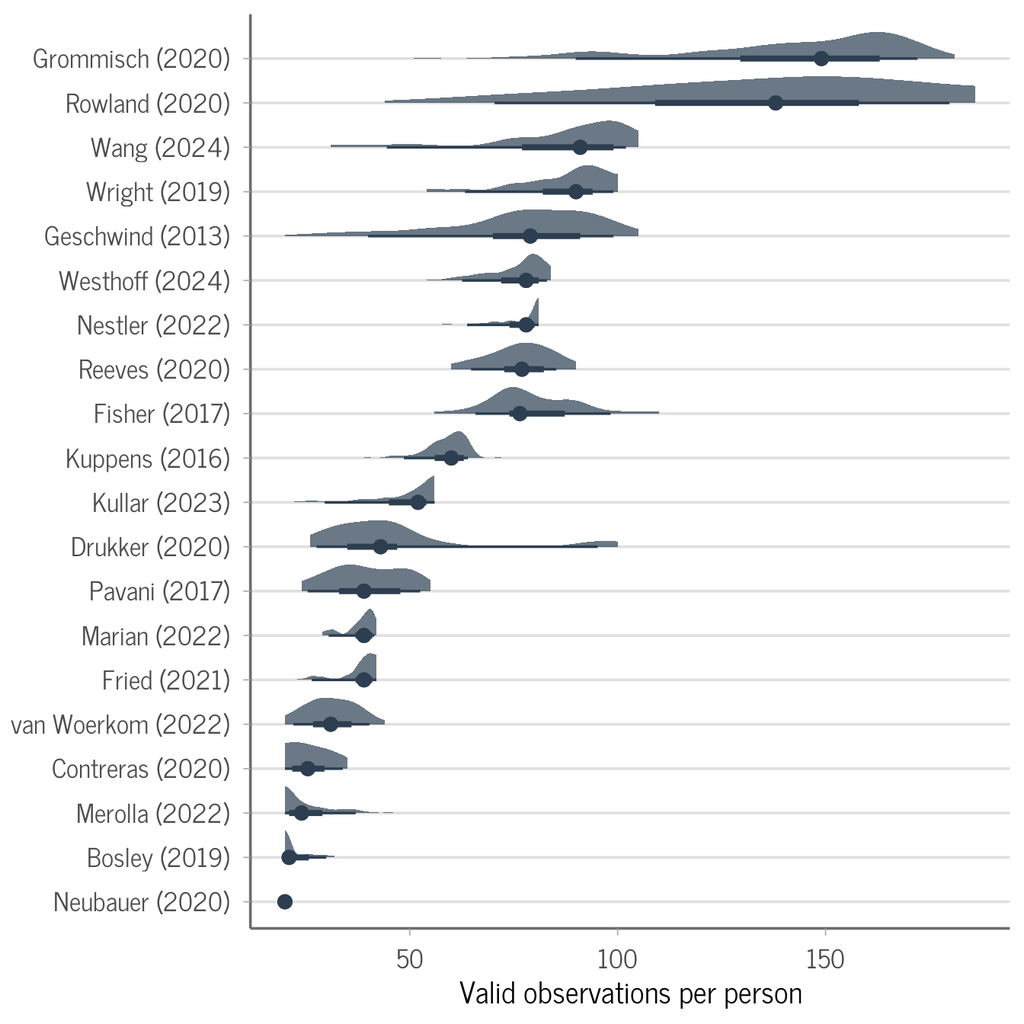

Figure 1: Valid observations per person, by dataset. Valid observations are timepoints with complete responses and a usable lag, not all scheduled beeps. Point: median; thick and thin lines: central 50% and 90% of persons.

```r
series_length <- features$person |>
  left_join(select(registry, dataset_id, label), by = "dataset_id") |>
  mutate(label = reorder(label, n_valid, FUN = median))

stopifnot(!anyNA(series_length$label))

ggplot(series_length, aes(x = n_valid, y = label)) +
  ggdist::stat_halfeye(normalize = "groups", scale = 0.6, .width = c(0.5, 0.9),
                       fill = "#2C3E50", slab_alpha = 0.7, point_size = 2.5, colour = "#2C3E50") +
  labs(x = "Valid observations per person", y = NULL) +
  theme_bs()
```

# 5 Missingness

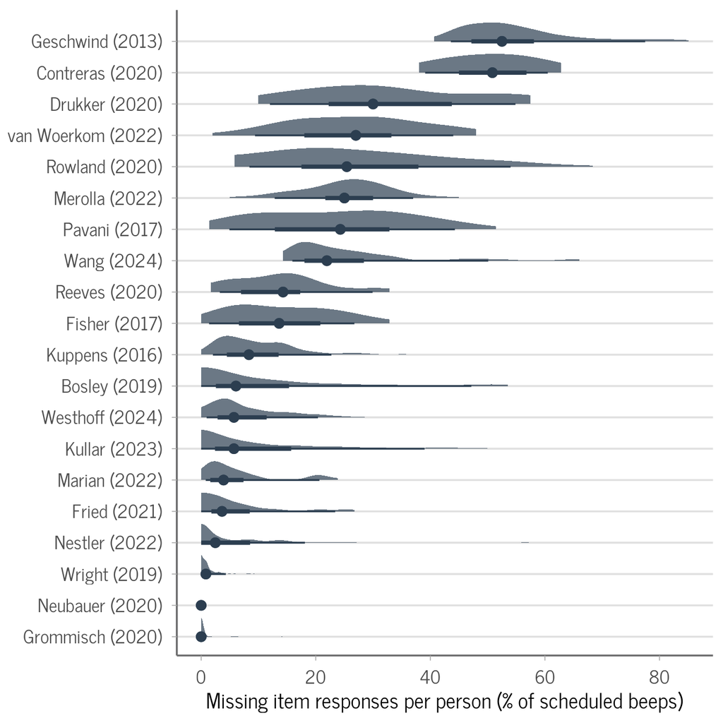

Figure 2: Share of missing item responses per person, by dataset, pooled over items and scheduled beeps from the person’s first to last recorded day, including beeps absent from the raw data. Scheduled days outside this span are unknown, so this may still underestimate missingness. Point: median; thick and thin lines: central 50% and 90% of persons.

```r
missingness <- features$series |>
  summarise(pct_missing = 100 * mean(is.na(y)), .by = c(dataset_id, id)) |>
  left_join(select(registry, dataset_id, label), by = "dataset_id") |>
  mutate(label = reorder(label, pct_missing, FUN = median))

stopifnot(!anyNA(missingness$label))

ggplot(missingness, aes(x = pct_missing, y = label)) +
  ggdist::stat_halfeye(density = "bounded", normalize = "groups", scale = 0.6,
                       .width = c(0.5, 0.9), fill = "#2C3E50", slab_alpha = 0.7,
                       point_size = 2.5, colour = "#2C3E50") +
  labs(x = "Missing item responses per person (% of scheduled beeps)", y = NULL) +
  theme_bs()
```